# scom-cam colab

```r
if (T) {
# load packages
library("tidyverse")
require(gridExtra)
library(grid)
library(viridis)
#library("quarto")
library("irr")
# clear workspace
rm(list=ls())
# load functions
source("../src/functions.R")
}
```

```
✖ purrr::%||%()   masks base::%||%()
```

### clean dataset

```r
# load dataset
#fn = "../csv/haidi-data-231012.csv"
fn = "../csv/haidi-data-231107.csv"
data = read.table(fn, sep='\t', header=T, strip.white=T, stringsAsFactors=F) |> as_tibble()
```

### news sources color maps

```r
#library(dplyr)
#library(ggplot2)
library(RColorBrewer)
library(purrr)  # For map()

# Data preparation
pd = data |>
  group_by(v03_news.source, v35_country) |>
  summarize(count = n()) |>
  left_join(dt03, by = join_by(v03_news.source == V2)) |>
  mutate(cn = paste(v35_country, V3),
         cc = as.factor(v35_country))
#
print(pd, n=Inf)
```

```
# A tibble: 15 × 7
# Groups:   v03_news.source [15]
   v03_news.source v35_country count V1          V3    cn     cc
             <int> <chr>       <int> <chr>       <chr> <chr>  <fct>
 1             101 se             13 News source DN    se DN  se
 2             102 se              9 News source AB    se AB  se
 3             103 se             16 News source VK    se VK  se
 4             104 se             12 News source GP    se GP  se
 5             105 se             10 News source SDS   se SDS se
 6             206 dk             28 News source PO    dk PO  dk
 7             207 dk              1 News source EB    dk EB  dk
 8             208 dk             10 News source FS    dk FS  dk
 9             209 dk              7 News source JV    dk JV  dk
10             210 dk              3 News source NJ    dk NJ  dk
11             311 fi             15 News source HS    fi HS  fi
12             312 fi              4 News source IS    fi IS  fi
13             313 fi             14 News source K     fi K   fi
14             314 fi             15 News source LK    fi LK  fi
15             315 fi             28 News source TS    fi TS  fi
```

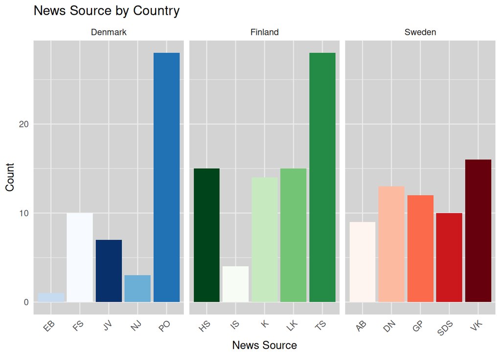

```r
# Define unique countries and palettes
countries <- unique(pd$v35_country)
palettes <- c("Blues", "Greens", "Reds")
names(palettes) <- countries  # Map palettes to countries: dk=Blues, fi=Greens, se=Reds

# Generate colors per group
pd <- pd %>%
  group_by(v35_country) %>%
  mutate(
    color_values = {
      palette_name <- palettes[unique(v35_country)]  # Get single palette for this group
      colors <- colorRampPalette(brewer.pal(9, palette_name))(n_distinct(V3))  # Generate color range
      colors[as.numeric(factor(V3))]  # Map colors to V3 levels
    }
  ) %>%
  ungroup()

# Plot with faceting, custom heatmaps, light gray background, mapped facet titles, no legend, and updated x-axis title
p1 = ggplot(pd, aes(x = V3, y = count, fill = cn)) +
  geom_bar(stat = "identity", position = "dodge") +
  facet_wrap(~ v35_country, scales = "free_x",
             labeller = labeller(v35_country = c("dk" = "Denmark", "fi" = "Finland", "se" = "Sweden"))) +
  scale_fill_manual(values = pd$color_values) +  # Removed legend name
  labs(y = "Count", x = "News Source", title = "News Source by Country") +
  theme_minimal() +
  theme(
    axis.text.x = element_text(angle = 45, hjust = 1),
    panel.background = element_rect(fill = "lightgray", colour = NA),  # Light gray background
    legend.position = "none"  # Exclude legend
  )

# Display the plot
p1
```

## 250306: index variable

```r
df <- data %>%
mutate(
v33_power.sum.index_reproduced = rowSums(select(., v22_actors.mentioned.given.voice.state.gov:v32_actors.mentioned.given.voice.other.citizen.family.relatives), na.rm = TRUE)
)

# Check if reproduced matches original
df <- df %>%
  mutate(match = v33_power.sum.index == v33_power.sum.index_reproduced)

# Summarize matches
table(df$match)
```

```
FALSE  TRUE
   17   168
```

```r
#write.table(df |> select(20, 21, v33_power.sum.index, v33_power.sum.index_reproduced, match), "tmp/index.csv", sep="\t", quot=T, row.names=F)
```

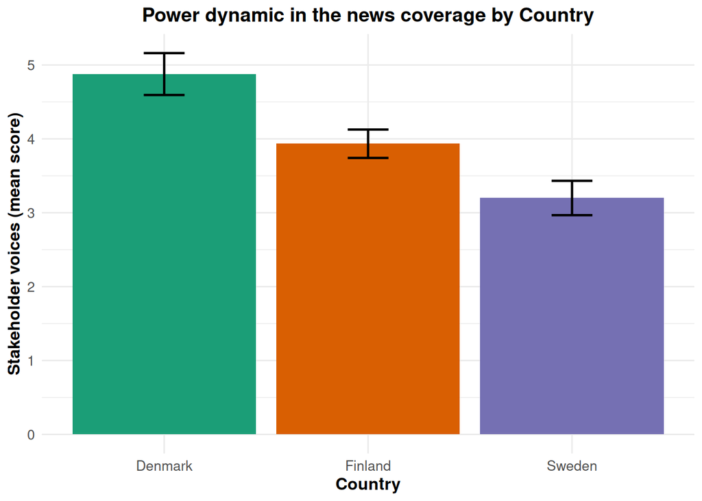

```r
library(dplyr)
library(ggplot2)
library(RColorBrewer)

# Data preparation: Select and rename columns
pd = data |>
  select(35, 33) |>
  rename(v35 = 1, v33 = 2)

# Calculate means and standard errors by country
pd_summary = pd |>
  group_by(v35) |>
  summarise(
    mean_v33 = mean(v33, na.rm = TRUE),
    se_v33 = sd(v33, na.rm = TRUE) / sqrt(n())  # Standard error of the mean
  ) |>
  mutate(
    country_name = recode(v35,
                          "dk" = "Denmark",
                          "fi" = "Finland",
                          "se" = "Sweden")
  )

# Bar plot with error bars using Dark2 palette
p1 = ggplot(pd_summary, aes(x = country_name, y = mean_v33, fill = country_name)) +
  geom_bar(stat = "identity", alpha = 1.0) +  # Bar plot for means
  geom_errorbar(aes(ymin = mean_v33 - se_v33, ymax = mean_v33 + se_v33),
                width = 0.2, size = 0.8) +  # Error bars for SEM
  scale_fill_brewer(palette = "Dark2") +  # Dark2 palette
  labs(
    y = "Stakeholder voices (mean score)",
    x = "Country",
    title = "Power dynamic in the news coverage by Country"
  ) +
  theme_minimal() +  # Clean theme
  theme(
    legend.position = "none",  # Remove legend (redundant with x-axis)
    axis.title = element_text(size = 12, face = "bold"),  # Bold, larger axis titles
    axis.text = element_text(size = 10),  # Clear axis labels
    plot.title = element_text(size = 14, face = "bold", hjust = 0.5)  # Centered, bold title
  )
# Display the plot
p1
```

```r
# Significance Test: ANOVA (since v35 has 3 levels: dk, fi, se)
anova_result <- aov(v33 ~ v35, data = pd)
summary(anova_result)
```

```
             Df Sum Sq Mean Sq F value   Pr(>F)
v35           2   75.9   37.96   11.68 1.69e-05 ***
Residuals   182  591.5    3.25
---
Signif. codes:  0 '***' 0.001 '**' 0.01 '*' 0.05 '.' 0.1 ' ' 1
```

```r
# Optional: Pairwise t-tests with Bonferroni correction (if you want specific group comparisons)
pairwise_t <- pairwise.t.test(pd$v33, pd$v35, p.adjust.method = "bonferroni")
print(pairwise_t)
```

```
    Pairwise comparisons using t tests with pooled SD

data:  pd$v33 and pd$v35

   dk      fi
fi 0.014   -
se 8.6e-06 0.058

P value adjustment method: bonferroni
```

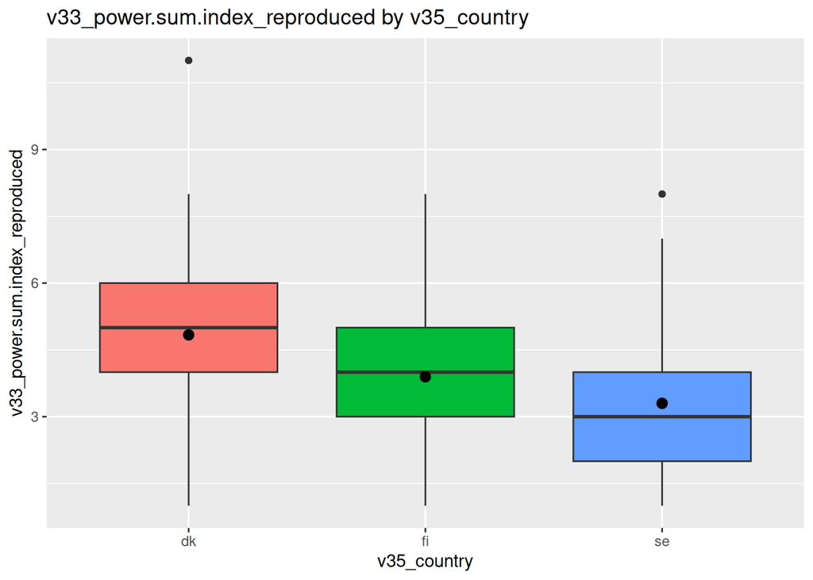

```r
#
pd = df |> select(35, v33_power.sum.index_reproduced) |> rename(v35=1, v33=2)
p1 = ggplot(pd, aes(x=v35, y=v33, fill=v35)) +
    geom_boxplot(alpha=1.0) +
    stat_summary(fun=mean) +
    labs(y="v33_power.sum.index_reproduced", x="v35_country", title="v33_power.sum.index_reproduced by v35_country") +
    theme(legend.position="none")

#
p1
```

## 250302: pretty diagrams

### frequency of categories

```
# A tibble: 10 × 9
# Groups:   v35_country [3]
   v35_country v04_article.type count   prop prop_lab count_lab V1            V2
   <chr>                  <int> <int>  <dbl>    <dbl>     <dbl> <chr>      <int>
 1 dk                         1    26 0.531    0.735       36   Article t…     1
 2 dk                         2     7 0.143    0.398       19.5 Article t…     2
 3 dk                         3     7 0.143    0.255       12.5 Article t…     3
 4 dk                         4     9 0.184    0.0918       4.5 Article t…     4
 5 fi                         1    59 0.776    0.612       46.5 Article t…     1
 6 fi                         2    14 0.184    0.132       10   Article t…     2
 7 fi                         3     3 0.0395   0.0197       1.5 Article t…     3
 8 se                         1    14 0.233    0.883       53   Article t…     1
 9 se                         2    34 0.567    0.483       29   Article t…     2
10 se                         3    12 0.2      0.1          6   Article t…     3
# ℹ 1 more variable: V3 <chr>
```

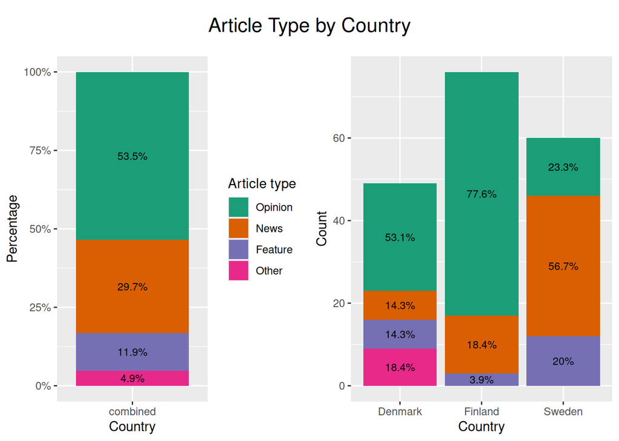

```
# A tibble: 9 × 9
# Groups:   v35_country [3]
  v35_country v05_article.size count   prop prop_lab count_lab V1       V2 V3
  <chr>                  <int> <int>  <dbl>    <dbl>     <dbl> <chr> <int> <chr>
1 dk                         1     7 0.143    0.929       45.5 Arti…     1 Small
2 dk                         2    19 0.388    0.663       32.5 Arti…     2 Medi…
3 dk                         3    23 0.469    0.235       11.5 Arti…     3 Large
4 fi                         1    47 0.618    0.691       52.5 Arti…     1 Small
5 fi                         2    24 0.316    0.224       17   Arti…     2 Medi…
6 fi                         3     5 0.0658   0.0329       2.5 Arti…     3 Large
7 se                         1     9 0.15     0.925       55.5 Arti…     1 Small
8 se                         2    10 0.167    0.767       46   Arti…     2 Medi…
9 se                         3    41 0.683    0.342       20.5 Arti…     3 Large
```

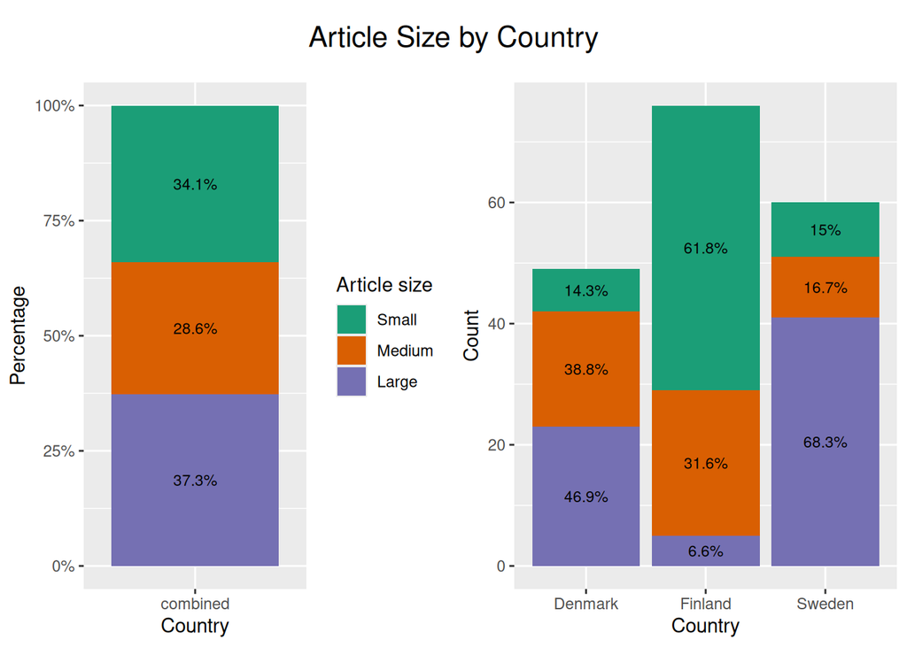

```
# A tibble: 9 × 9
# Groups:   v35_country [3]
  v35_country v06_illustrated count   prop prop_lab count_lab V1        V2 V3
  <chr>                 <int> <int>  <dbl>    <dbl>     <dbl> <chr>  <int> <chr>
1 dk                        0    14 0.286    0.857       42   Illus…     0 No
2 dk                        1    23 0.469    0.480       23.5 Illus…     1 Yes,…
3 dk                        2    12 0.245    0.122        6   Illus…     2 Yes …
4 fi                        0    49 0.645    0.678       51.5 Illus…     0 No
5 fi                        1    25 0.329    0.191       14.5 Illus…     1 Yes,…
6 fi                        2     2 0.0263   0.0132       1   Illus…     2 Yes …
7 se                        0     3 0.0508   0.975       57.5 Illus…     0 No
8 se                        1    52 0.881    0.508       30   Illus…     1 Yes,…
9 se                        2     4 0.0678   0.0339       2   Illus…     2 Yes …
```

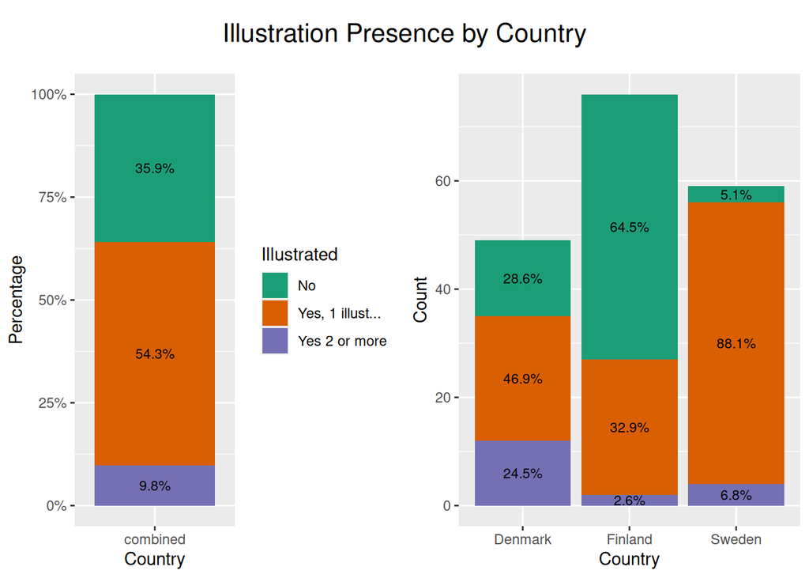

```
# A tibble: 11 × 9
# Groups:   v35_country [3]
   v35_country v07_type.of.illustration count   prop prop_lab count_lab V1
   <chr>                          <int> <int>  <dbl>    <dbl>     <dbl> <chr>
 1 dk                                 1    15 0.429   0.786        27.5 Type of…
 2 dk                                 2     3 0.0857  0.529        18.5 Type of…
 3 dk                                 3     9 0.257   0.357        12.5 Type of…
 4 dk                                 4     6 0.171   0.143         5   Type of…
 5 dk                                 5     2 0.0571  0.0286        1   Type of…
 6 fi                                 1    14 0.538   0.731        19   Type of…
 7 fi                                 2    12 0.462   0.231         6   Type of…
 8 se                                 1    38 0.679   0.661        37   Type of…
 9 se                                 2    15 0.268   0.187        10.5 Type of…
10 se                                 4     2 0.0357  0.0357        2   Type of…
11 se                                 5     1 0.0179  0.00893       0.5 Type of…
# ℹ 2 more variables: V2 <int>, V3 <chr>
```

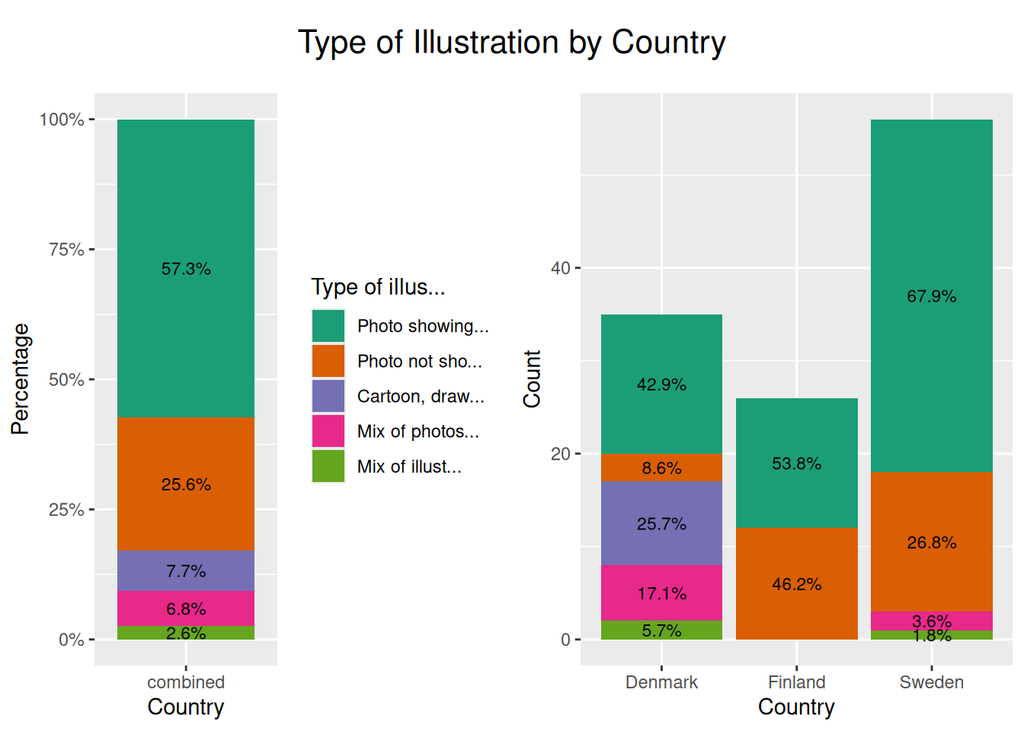

```
# A tibble: 6 × 9
# Groups:   v35_country [3]
  v35_country v08_target.group.in.…¹ count   prop prop_lab count_lab V1       V2
  <chr>                        <int> <int>  <dbl>    <dbl>     <dbl> <chr> <int>
1 dk                               0    27 0.931    0.534       15.5 Targ…     0
2 dk                               1     2 0.0690   0.0345       1   Targ…     1
3 fi                               0     4 0.267    0.867       13   Targ…     0
4 fi                               1    11 0.733    0.367        5.5 Targ…     1
5 se                               0    39 0.696    0.652       36.5 Targ…     0
6 se                               1    17 0.304    0.152        8.5 Targ…     1
# ℹ abbreviated name: ¹v08_target.group.in.illustration
# ℹ 1 more variable: V3 <chr>
```

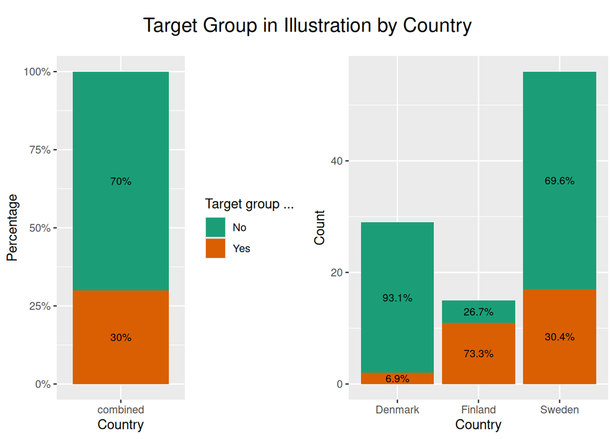

```
# A tibble: 6 × 9
# Groups:   v35_country [3]
  v35_country v09_agency.of.target…¹ count   prop prop_lab count_lab V1       V2
  <chr>                        <int> <int>  <dbl>    <dbl>     <dbl> <chr> <int>
1 dk                               0     1 0.5       0.75        1.5 Agen…     0
2 dk                               1     1 0.5       0.25        0.5 Agen…     1
3 fi                               0     1 0.0909    0.955      10.5 Agen…     0
4 fi                               1    10 0.909     0.455       5   Agen…     1
5 se                               0     7 0.412     0.794      13.5 Agen…     0
6 se                               1    10 0.588     0.294       5   Agen…     1
# ℹ abbreviated name: ¹v09_agency.of.target.group.in.illustration
# ℹ 1 more variable: V3 <chr>
```

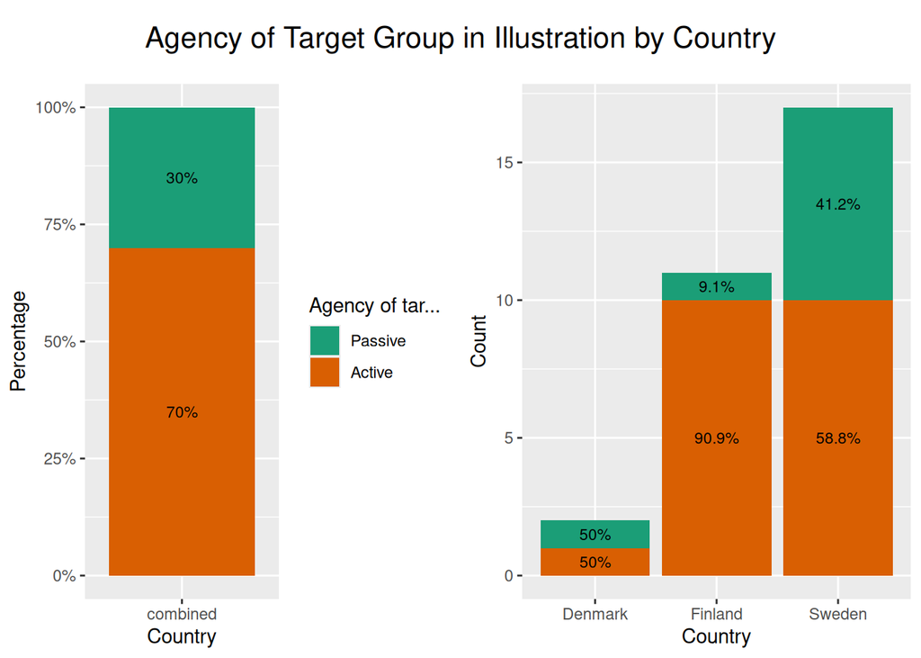

```
# A tibble: 6 × 9
# Groups:   v35_country [3]
  v35_country v12_heading.content.…¹ count   prop prop_lab count_lab V1       V2
  <chr>                        <int> <int>  <dbl>    <dbl>     <dbl> <chr> <int>
1 dk                               0    42 0.857    0.571       28   Head…     0
2 dk                               1     7 0.143    0.0714       3.5 Head…     1
3 fi                               0    67 0.882    0.559       42.5 Head…     0
4 fi                               1     9 0.118    0.0592       4.5 Head…     1
5 se                               0    56 0.933    0.533       32   Head…     0
6 se                               1     4 0.0667   0.0333       2   Head…     1
# ℹ abbreviated name: ¹v12_heading.content.health
# ℹ 1 more variable: V3 <chr>
```

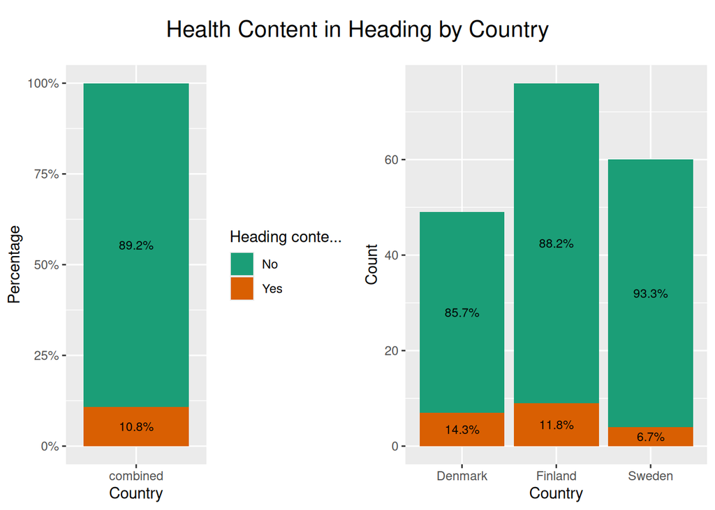

```
# A tibble: 6 × 9
# Groups:   v35_country [3]
  v35_country v13_heading.content.…¹ count   prop prop_lab count_lab V1       V2
  <chr>                        <int> <int>  <dbl>    <dbl>     <dbl> <chr> <int>
1 dk                               0    46 0.939    0.531       26   Head…     0
2 dk                               1     3 0.0612   0.0306       1.5 Head…     1
3 fi                               0    57 0.75     0.625       47.5 Head…     0
4 fi                               1    19 0.25     0.125        9.5 Head…     1
5 se                               0    44 0.733    0.633       38   Head…     0
6 se                               1    16 0.267    0.133        8   Head…     1
# ℹ abbreviated name: ¹v13_heading.content.old
# ℹ 1 more variable: V3 <chr>
```

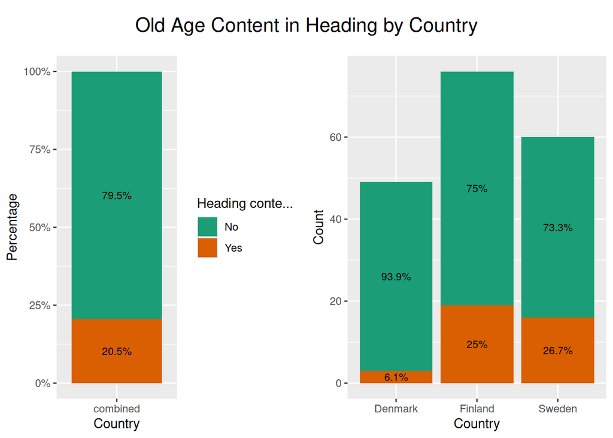

```
# A tibble: 6 × 9
# Groups:   v35_country [3]
  v35_country v14_heading.content.d…¹ count  prop prop_lab count_lab V1       V2
  <chr>                         <int> <int> <dbl>    <dbl>     <dbl> <chr> <int>
1 dk                                0    34 0.694    0.653      32   Head…     0
2 dk                                1    15 0.306    0.153       7.5 Head…     1
3 fi                                0    48 0.632    0.684      52   Head…     0
4 fi                                1    28 0.368    0.184      14   Head…     1
5 se                                0    44 0.733    0.633      38   Head…     0
6 se                                1    16 0.267    0.133       8   Head…     1
# ℹ abbreviated name: ¹v14_heading.content.digital.tekn
# ℹ 1 more variable: V3 <chr>
```

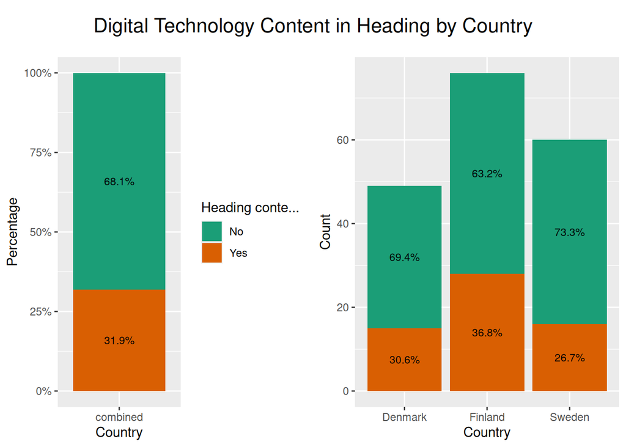

```
# A tibble: 5 × 9
# Groups:   v35_country [3]
  v35_country v15_heading.content.…¹ count   prop prop_lab count_lab V1       V2
  <chr>                        <int> <int>  <dbl>    <dbl>     <dbl> <chr> <int>
1 dk                               0    49 1       0.5          24.5 Head…     0
2 fi                               0    75 0.987   0.507        38.5 Head…     0
3 fi                               1     1 0.0132  0.00658       0.5 Head…     1
4 se                               0    55 0.917   0.542        32.5 Head…     0
5 se                               1     5 0.0833  0.0417        2.5 Head…     1
# ℹ abbreviated name: ¹v15_heading.content.ill
# ℹ 1 more variable: V3 <chr>
```

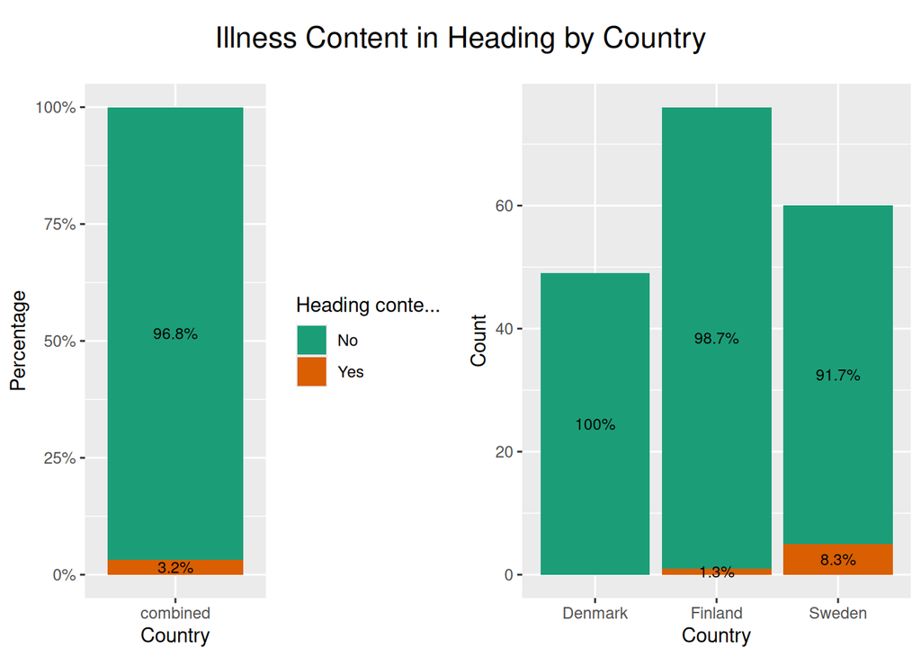

```
# A tibble: 28 × 9
# Groups:   v35_country [3]
   v35_country v18_article.content.domin…¹ count   prop prop_lab count_lab V1
   <chr>                             <int> <int>  <dbl>    <dbl>     <dbl> <chr>
 1 dk                                    1     6 0.122    0.939       46   Arti…
 2 dk                                    2     1 0.0204   0.867       42.5 Arti…
 3 dk                                    3    14 0.286    0.714       35   Arti…
 4 dk                                    4     1 0.0204   0.561       27.5 Arti…
 5 dk                                    5     1 0.0204   0.541       26.5 Arti…
 6 dk                                    6     1 0.0204   0.520       25.5 Arti…
 7 dk                                    8     3 0.0612   0.480       23.5 Arti…
 8 dk                                    9     1 0.0204   0.439       21.5 Arti…
 9 dk                                   10     8 0.163    0.347       17   Arti…
10 dk                                   12    13 0.265    0.133        6.5 Arti…
11 fi                                    1     9 0.138    0.931       60.5 Arti…
```

[output cut: 19 more lines]

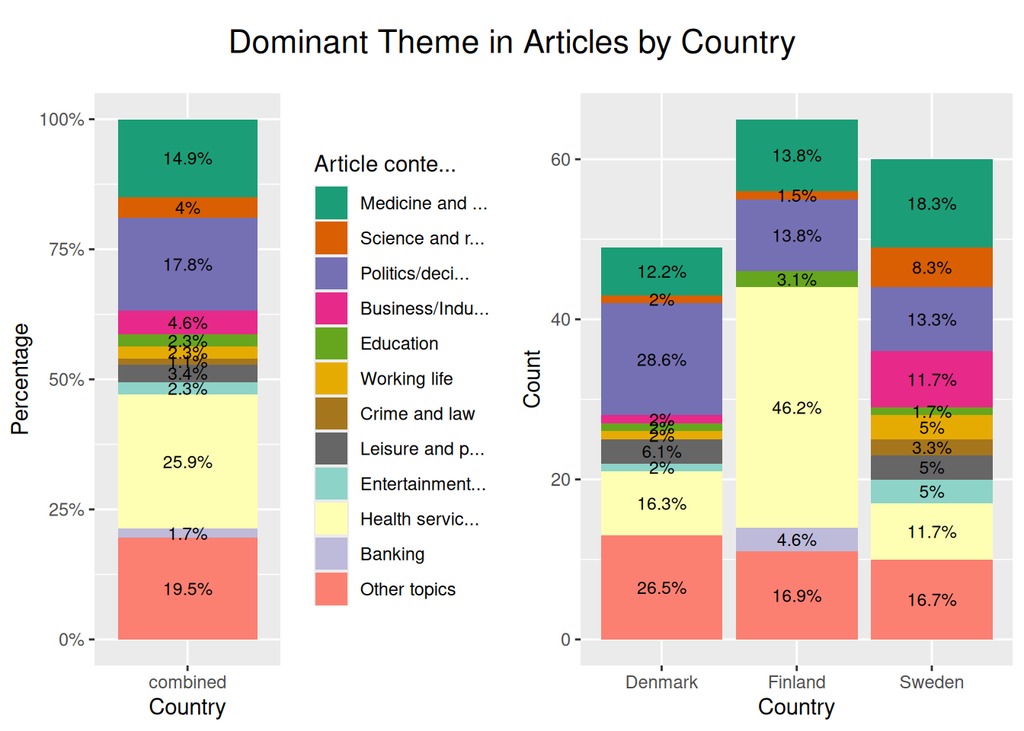

```
# A tibble: 20 × 9
# Groups:   v35_country [3]
   v35_country v19_subject.positioning count   prop prop_lab count_lab V1
   <chr>                         <int> <int>  <dbl>    <dbl>     <dbl> <chr>
 1 dk                                1    24 0.774    0.613       19   Subject …
 2 dk                                3     3 0.0968   0.177        5.5 Subject …
 3 dk                                6     1 0.0323   0.113        3.5 Subject …
 4 dk                                9     3 0.0968   0.0484       1.5 Subject …
 5 fi                                1    59 0.787    0.607       45.5 Subject …
 6 fi                                2     2 0.0267   0.2         15   Subject …
 7 fi                                3     2 0.0267   0.173       13   Subject …
 8 fi                                4     2 0.0267   0.147       11   Subject …
 9 fi                                8     2 0.0267   0.12         9   Subject …
10 fi                                9     5 0.0667   0.0733       5.5 Subject …
11 fi                               11     3 0.04     0.02         1.5 Subject …
12 se                                1    40 0.667    0.667       40   Subject …
13 se                                2     2 0.0333   0.317       19   Subject …
14 se                                3     5 0.0833   0.258       15.5 Subject …
15 se                                4     1 0.0167   0.208       12.5 Subject …
16 se                                5     4 0.0667   0.167       10   Subject …
17 se                                6     2 0.0333   0.117        7   Subject …
18 se                                7     2 0.0333   0.0833       5   Subject …
19 se                                8     2 0.0333   0.05         3   Subject …
20 se                                9     2 0.0333   0.0167       1   Subject …
# ℹ 2 more variables: V2 <int>, V3 <chr>
```

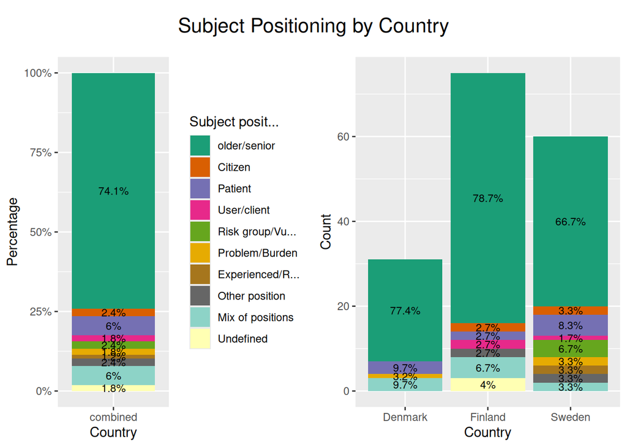

```
# A tibble: 5 × 9
# Groups:   v35_country [3]
  v35_country v20_agency.of.target.…¹ count  prop prop_lab count_lab V1       V2
  <chr>                         <int> <int> <dbl>    <dbl>     <dbl> <chr> <int>
1 dk                                0    49 1       0.5         24.5 Agen…     0
2 fi                                0    62 0.816   0.592       45   Agen…     0
3 fi                                1    14 0.184   0.0921       7   Agen…     1
4 se                                0    53 0.883   0.558       33.5 Agen…     0
5 se                                1     7 0.117   0.0583       3.5 Agen…     1
# ℹ abbreviated name: ¹v20_agency.of.target.group.in.article.voice
# ℹ 1 more variable: V3 <chr>
```

[14 more figures not shown]

```
# A tibble: 8 × 9
# Groups:   v35_country [3]
  v35_country v34_tonality.of.arti…¹ count   prop prop_lab count_lab V1       V2
  <chr>                        <int> <int>  <dbl>    <dbl>     <dbl> <chr> <int>
1 dk                               1    22 0.449    0.776       38   Tona…     1
2 dk                               2    24 0.490    0.306       15   Tona…     2
3 dk                               3     3 0.0612   0.0306       1.5 Tona…     3
4 fi                               1    26 0.342    0.829       63   Tona…     1
5 fi                               2    33 0.434    0.441       33.5 Tona…     2
6 fi                               3    17 0.224    0.112        8.5 Tona…     3
7 se                               1    20 0.333    0.833       50   Tona…     1
8 se                               2    40 0.667    0.333       20   Tona…     2
# ℹ abbreviated name: ¹v34_tonality.of.article
# ℹ 1 more variable: V3 <chr>
```

```r
#if (!requireNamespace("colorblindr", quietly = TRUE)) install.packages("colorblindr", lib="~/lib/r-cran")
#library(ggplot2)
#library(gridExtra)
#library(dplyr)  # For string manipulation and recode
#library(stringr)  # For str_trunc
#library(colorblindr)  # For extended Okabe-Ito palette
library(RColorBrewer)  # For ColorBrewer palettes

# get graphs
for (i in c(4:9,12:15,18:21,22:32,34)) {
pd = desc_get_brewer(data, get(paste0("dt",sprintf("%02d", i))), i, var_pl=T)

# get table
#print(pd[2])
#cat(knitr::kable(pd[[2]]))
print(pd[[2]], n = Inf)
#
write.table(pd[2], paste0("../tmp/haidi-table-v", sprintf("%02d", i), ".csv"), sep="\t", quot=T, row.names=F)
}
```

```bash
cat ../tmp/haidi-table-* > ../tmp/haidi-tables.csv
```

## 250210: chi square tests

### v04_article.type, count values by country and article type

Below is a summary interpretation of the chi-square test results:

- **Test Statistic and Significance:**  
  The chi-square statistic is 72.89 with 6 degrees of freedom. The associated p-value is extremely small (approximately 1.04 × 10⁻¹³), which is far below any conventional significance level (e.g., 0.05). This provides strong evidence to reject the null hypothesis of independence.
- **Interpretation:**  
  The results indicate that there is a statistically significant association between country (dk, fi, se) and article type (1, 2, 3, 4). In other words, the distribution of article types is not uniform across the three countries.
- **Observed vs. Expected Frequencies:**  
  The contingency table shows notable differences between observed counts and expected counts under the assumption of independence. For example:
  - In Denmark (dk), article type 2 was observed only 7 times while about 14.57 were expected, and article type 4 was observed 9 times compared to an expected 2.38.
  - In Finland (fi), article type 1 appears more frequently (observed 59 vs. expected 40.67), and no articles of type 4 were observed even though about 3.70 were expected.
  - In Sweden (se), article type 2 is observed 34 times, which is much higher than the expected count of about 17.84.
- **Conclusion:**  
  The chi-square test clearly demonstrates that the type of article published is associated with the country. This suggests that factors related to the country may influence the distribution of article types.

In summary, the analysis shows that the differences in article type counts across Denmark, Finland, and Sweden are unlikely to be due to chance, pointing to a meaningful relationship between country and article type.

### v05_article.size, count values by country and article size

The chi-square test yielded a statistic of approximately 70.19 with 4 degrees of freedom and a p-value of about 2.07×10⁻¹⁴. This extremely small p-value indicates that there is a statistically significant association between country (dk, fi, se) and article size (small, medium, large). In other words, the observed distribution of article sizes across the three countries is very unlikely to have occurred by chance if the two variables were independent.

**Key Observations:**

- **Denmark (dk):**
  - Observed counts: 7 (small), 19 (medium), 23 (large)
  - Expected counts under independence: approximately 16.69 (small), 14.04 (medium), 18.28 (large)  
    The observed count for small articles is lower than expected, while medium and large are higher than expected.
- **Finland (fi):**
  - Observed counts: 47 (small), 24 (medium), 5 (large)
  - Expected counts: approximately 25.88 (small), 21.77 (medium), 28.35 (large)  
    Here, there is an excess of small articles and a deficit of large articles compared to the expected frequencies.
- **Sweden (se):**
  - Observed counts: 9 (small), 10 (medium), 41 (large)
  - Expected counts: approximately 20.43 (small), 17.19 (medium), 22.38 (large)  
    In Sweden, the observed count for large articles is much higher than expected, while small and medium counts are lower.

**Conclusion:**

The significant chi-square test result indicates that the distribution of article sizes is not independent of country. The differences between the observed and expected frequencies suggest that each country has a distinct pattern in article size distribution. For example, Finland appears to favor small articles, whereas Sweden shows a strong tendency toward large articles. These differences are statistically significant and suggest that factors related to each country may be influencing the article size choices.

### v06_illustrated

The chi-square test produced a statistic of approximately 68.33 with 4 degrees of freedom and an extremely small p-value (≈ 5.12×10⁻¹⁴). This means we reject the null hypothesis of independence and conclude that there is a statistically significant association between country and illustration status.

**Key Observations:**

- **Overall Significance:**  
  The p-value is far below any conventional significance threshold (e.g., 0.05), indicating that the differences in illustration status across countries are highly unlikely to be due to chance.
- **Country-Specific Patterns:**
  - **Denmark (dk):**
    - Observed counts: 14 (no illustration, 0), 23 (one illustration, 1), 12 (two or more illustrations, 2).
    - Expected counts: approximately 17.58, 26.63, and 4.79 respectively.
    - **Interpretation:** Denmark shows a notable excess in the highest illustration category (v06_illustrated = 2) compared to expectations.
  - **Finland (fi):**
    - Observed counts: 49 (0), 25 (1), 2 (2).
    - Expected counts: approximately 27.26, 41.30, and 7.43 respectively.
    - **Interpretation:** Finland has many more articles with no illustrations (v06_illustrated = 0) and far fewer with one or multiple illustrations than expected.
  - **Sweden (se):**
    - Observed counts: 3 (0), 52 (1), 4 (2).
    - Expected counts: approximately 21.16, 32.07, and 5.77 respectively.
    - **Interpretation:** Sweden has far fewer non-illustrated articles than expected and a higher count for the one illustration category.

**Conclusion:**

There is clear evidence that the distribution of illustration status (v06_illustrated) differs significantly by country. Denmark tends to publish a higher proportion of articles with two or more illustrations than expected, Finland tends to have a high proportion of articles with no illustrations, and Sweden shows an overrepresentation in the one illustration category. These differences suggest that country-specific factors or editorial practices may be influencing the use of illustrations.

### v07_type.of.illu

The chi-square test produced a statistic of approximately 42.02 with 8 degrees of freedom and an extremely small p-value (≈ 1.34×10⁻⁶). This provides very strong evidence against the null hypothesis of independence, indicating that the distribution of illustration types (v07_type_of_illustration) is significantly different across the three countries.

**Key Points:**

- **Overall Significance:**  
  With a p-value far below conventional significance thresholds (e.g., 0.05), we conclude that the type of illustration used is not independent of the country. In other words, the distribution of illustration types varies significantly by country.
- **Observed vs. Expected Frequencies:**
  - **Denmark (dk):**
    - **Type 1:** Observed 15 vs. Expected ≈ 20.04
    - **Type 3:** Observed 9 vs. Expected ≈ 2.69
    - **Type 4:** Observed 6 vs. Expected ≈ 2.39
    - **Type 5:** Observed 2 vs. Expected ≈ 0.90  
      These differences suggest that Denmark has fewer type 1 illustrations and considerably more type 3 and type 4 illustrations than would be expected if there were no association.
  - **Finland (fi):**
    - **Type 1:** Observed 14 vs. Expected ≈ 14.89
    - **Type 2:** Observed 12 vs. Expected ≈ 6.67
    - No articles were observed for types 3, 4, or 5, whereas some counts were expected (e.g., type 3 expected ≈ 2.00).  
      This indicates that Finland has an overrepresentation of type 2 illustrations and a lack of articles in the higher illustration categories.
  - **Sweden (se):**
    - **Type 1:** Observed 38 vs. Expected ≈ 32.07
    - **Type 2:** Observed 15 vs. Expected ≈ 14.36
    - **Type 3:** Observed 0 vs. Expected ≈ 4.31
    - **Type 4:** Observed 2 vs. Expected ≈ 3.83
    - **Type 5:** Observed 1 vs. Expected ≈ 1.44  
      For Sweden, the count for type 1 is slightly higher than expected, while there are fewer type 3 illustrations than expected.

**Conclusion:**

The significant chi-square statistic indicates that the type of illustration is associated with the country. Each country shows a distinct pattern: - **Denmark** appears to favor higher counts in types 3 and 4. - **Finland** shows a strong emphasis on type 2 illustrations with a near absence of higher illustration categories. - **Sweden** has a relatively high count of type 1 illustrations and lower counts for type 3.

These findings suggest that country-specific factors or editorial policies may influence the choice or prevalence of illustration types in articles.

### v08_target.group

```r
# Read the table data directly from text into a dataframe
data <- read.table(text = "
v35_country v08_target.group.in.illustration count
dk          0                                27
dk          1                                 2
fi          0                                 4
fi          1                                11
se          0                                39
se          1                                17
", header = TRUE, stringsAsFactors = FALSE)

# Check the dataframe
print(data)
```

```
  v35_country v08_target.group.in.illustration count
1          dk                                0    27
2          dk                                1     2
3          fi                                0     4
4          fi                                1    11
5          se                                0    39
6          se                                1    17
```

```r
# Create a contingency table from the count data
contingency_table <- xtabs(count ~ v35_country + v08_target.group.in.illustration, data = data)

# Display the contingency table
print(contingency_table)
```

```
           v08_target.group.in.illustration
v35_country  0  1
         dk 27  2
         fi  4 11
         se 39 17
```

```r
# Perform chi-square test of independence
chi_test <- chisq.test(contingency_table)
# Print the test results
print(chi_test)
```

```
    Pearson's Chi-squared test

data:  contingency_table
X-squared = 20.787, df = 2, p-value = 3.063e-05
```

```r
# Check expected counts to ensure test validity
print(chi_test$expected)
```

```
           v08_target.group.in.illustration
v35_country    0    1
         dk 20.3  8.7
         fi 10.5  4.5
         se 39.2 16.8
```

The chi-square test produced a statistic of about 20.79 with 2 degrees of freedom and a very small p-value (≈ 3.06×10⁻⁵). This p-value is far below any common significance threshold (e.g., 0.05), meaning we reject the null hypothesis that the country and target group in illustration are independent.

**Key Points:**

- **Statistical Significance:**  
  The small p-value indicates that the observed differences in target group distribution across the three countries (dk, fi, se) are unlikely to have occurred by chance.
- **Observed vs. Expected Frequencies:**
  - For Denmark (dk):
    - Observed: 27 for group 0 and 2 for group 1
    - Expected: Approximately 20.3 for group 0 and 8.7 for group 1  
      This suggests Denmark has more group 0 and fewer group 1 articles than expected under independence.
  - For Finland (fi):
    - Observed: 4 for group 0 and 11 for group 1
    - Expected: About 10.5 for group 0 and 4.5 for group 1  
      This indicates Finland has an overrepresentation of group 1 and an underrepresentation of group 0.
  - For Sweden (se):
    - Observed: 39 for group 0 and 17 for group 1
    - Expected: Roughly 39.2 for group 0 and 16.8 for group 1  
      The observed counts for Sweden are very close to what would be expected.
- **Overall Interpretation:**  
  The significant chi-square test result tells us that the distribution of the target group in illustration (group 0 vs. group 1) differs by country. Denmark and Finland show marked deviations from the expected frequencies under the assumption of independence, while Sweden’s distribution is close to the expected values. This indicates that country-specific factors may be influencing the categorization into target groups.

In summary, there is strong evidence of an association between the country and the target group in illustration.

### v09_agency.of.target.group.in.illustration

```r
# Read the table data directly from text into a dataframe
data <- read.table(text = "
v35_country v09_agency.of.target.group.in.illustration count
dk          0                                            1
dk          1                                            1
fi          0                                            1
fi          1                                           10
se          0                                            7
se          1                                           10
", header = TRUE, stringsAsFactors = FALSE)

# Check the dataframe
print(data)
```

```
  v35_country v09_agency.of.target.group.in.illustration count
1          dk                                          0     1
2          dk                                          1     1
3          fi                                          0     1
4          fi                                          1    10
5          se                                          0     7
6          se                                          1    10
```

```r
# Create a contingency table from the count data
contingency_table <- xtabs(count ~ v35_country + v09_agency.of.target.group.in.illustration, data = data)

# Display the contingency table
print(contingency_table)
```

```
           v09_agency.of.target.group.in.illustration
v35_country  0  1
         dk  1  1
         fi  1 10
         se  7 10
```

```r
# Perform chi-square test of independence
chi_test <- chisq.test(contingency_table)
# Print the test results
print(chi_test)
```

```
    Pearson's Chi-squared test

data:  contingency_table
X-squared = 3.6822, df = 2, p-value = 0.1586
```

```r
# Optional: Check expected counts to ensure test validity
print(chi_test$expected)
```

```
           v09_agency.of.target.group.in.illustration
v35_country   0    1
         dk 0.6  1.4
         fi 3.3  7.7
         se 5.1 11.9
```

### v12_heading.content.health

```
  v35_country v12_heading.content.health count
1          dk                          0    42
2          dk                          1     7
3          fi                          0    67
4          fi                          1     9
5          se                          0    56
6          se                          1     4
```

```
           v12_heading.content.health
v35_country  0  1
         dk 42  7
         fi 67  9
         se 56  4
```

```
    Pearson's Chi-squared test

data:  contingency_table
X-squared = 1.7662, df = 2, p-value = 0.4135
```

```
           v12_heading.content.health
v35_country        0        1
         dk 43.70270 5.297297
         fi 67.78378 8.216216
         se 53.51351 6.486486
```

### v13_heading.content.old

### v14_heading.content.digital.tekn

### v15_heading.content.ill

### v16_digital.media.and.technology

### v17_digital.health.technologies

### v18_article.content.dominant.theme

```
   v35_country v18_article.content.dominant.theme count
1           dk                                  1     6
2           dk                                  2     1
3           dk                                  3    14
4           dk                                  4     1
5           dk                                  5     1
6           dk                                  6     1
7           dk                                  8     3
8           dk                                  9     1
9           dk                                 10     8
10          dk                                 12    13
11          fi                                  1     9
12          fi                                  2     1
13          fi                                  3     9
14          fi                                  5     2
15          fi                                 10    30
16          fi                                 11     3
17          fi                                 12    11
18          se                                  1    11
19          se                                  2     5
20          se                                  3     8
21          se                                  4     7
22          se                                  5     1
23          se                                  6     3
24          se                                  7     2
25          se                                  8     3
26          se                                  9     3
27          se                                 10     7
28          se                                 12    10
```

```
           v18_article.content.dominant.theme
v35_country  1  2  3  4  5  6  7  8  9 10 11 12
         dk  6  1 14  1  1  1  0  3  1  8  0 13
         fi  9  1  9  0  2  0  0  0  0 30  3 11
         se 11  5  8  7  1  3  2  3  3  7  0 10
```

```
    Pearson's Chi-squared test

data:  contingency_table
X-squared = 57.715, df = 22, p-value = 4.835e-05
```

```
           v18_article.content.dominant.theme
v35_country        1        2         3        4        5        6         7
         dk 7.321839 1.971264  8.729885 2.252874 1.126437 1.126437 0.5632184
         fi 9.712644 2.614943 11.580460 2.988506 1.494253 1.494253 0.7471264
         se 8.965517 2.413793 10.689655 2.758621 1.379310 1.379310 0.6896552
           v18_article.content.dominant.theme
v35_country        8        9       10        11        12
         dk 1.689655 1.126437 12.67241 0.8448276  9.574713
         fi 2.241379 1.494253 16.81034 1.1206897 12.701149
         se 2.068966 1.379310 15.51724 1.0344828 11.724138
```

```
    Fisher's Exact Test for Count Data with simulated p-value (based on
    2000 replicates)

data:  contingency_table
p-value = 0.0004998
alternative hypothesis: two.sided
```

### v20_agency.of.target.group.in.article.voice

```
  v35_country v20_agency.of.target.group.in.article.voice count
1          dk                                           0    49
2          fi                                           0    62
3          fi                                           1    14
4          se                                           0    53
5          se                                           1     7
```

```
           v20_agency.of.target.group.in.article.voice
v35_country  0  1
         dk 49  0
         fi 62 14
         se 53  7
```

```
    Pearson's Chi-squared test

data:  contingency_table
X-squared = 10.055, df = 2, p-value = 0.006555
```

```
           v20_agency.of.target.group.in.article.voice
v35_country        0        1
         dk 43.43784 5.562162
         fi 67.37297 8.627027
         se 53.18919 6.810811
```

```
    Fisher's Exact Test for Count Data with simulated p-value (based on
    2000 replicates)

data:  contingency_table
p-value = 0.003498
alternative hypothesis: two.sided
```

### v34_tonality.of.article

```
  v35_country v34_tonality.of.article count
1          dk                       1    22
2          dk                       2    24
3          dk                       3     3
4          fi                       1    26
5          fi                       2    33
6          fi                       3    17
7          se                       1    20
8          se                       2    40
```

```
           v34_tonality.of.article
v35_country  1  2  3
         dk 22 24  3
         fi 26 33 17
         se 20 40  0
```

```
    Pearson's Chi-squared test

data:  contingency_table
X-squared = 21.689, df = 4, p-value = 0.0002311
```

```
           v34_tonality.of.article
v35_country        1        2        3
         dk 18.01081 25.69189 5.297297
         fi 27.93514 39.84865 8.216216
         se 22.05405 31.45946 6.486486
```

```
    Fisher's Exact Test for Count Data with simulated p-value (based on
    2000 replicates)

data:  contingency_table
p-value = 0.0004998
alternative hypothesis: two.sided
```